# Lab 9 - Linear and Multivariate Models

## Lab Objectives:

- Examining residuals in regressions
- Dealing with outliers in regressions
- Adding variables to linear models

# Checking assumptions from a regression

Blue tit cap color

Create a residual plot to check assumptions. The data are cap color of offspring and parents in a sample of the blue tit.

Read and inspect the data.

```r
d <- read.csv("capcolour.csv")
```

Basic scatter plot with regression line.

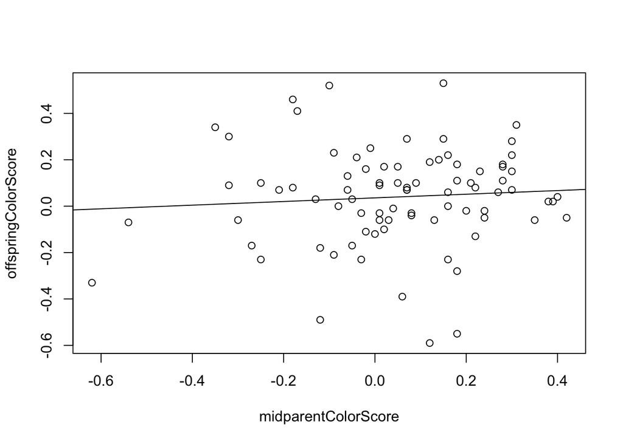

```r
plot(offspringColorScore ~ midparentColorScore, data = d)
capColorRegression <- lm(offspringColorScore ~ midparentColorScore, data = d)
abline(capColorRegression)
```

Residual plot. Residuals are calculated from the model object created from the previous lm command, using the residuals command.

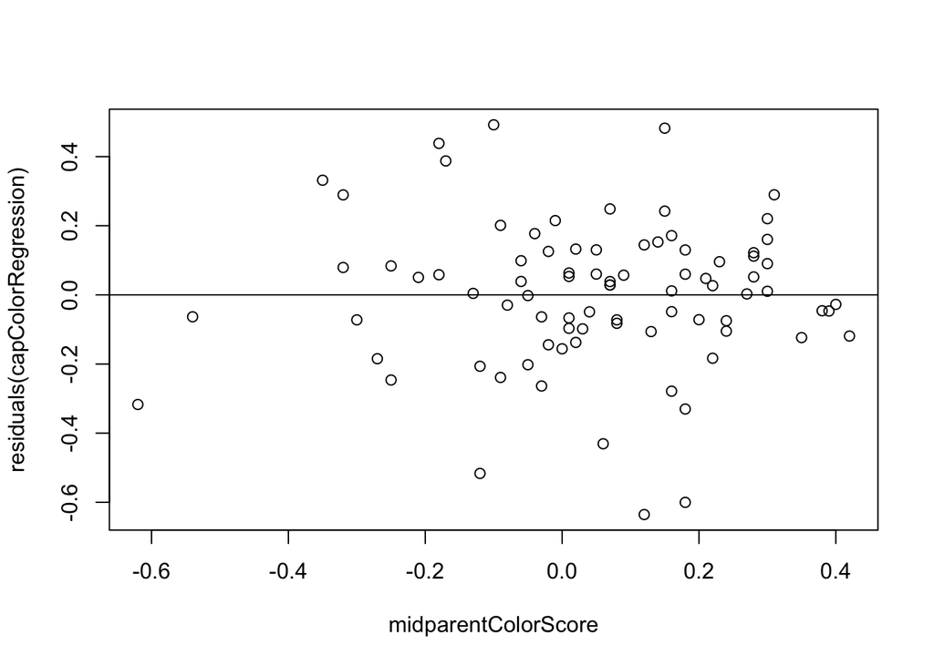

```r
plot(residuals(capColorRegression) ~ midparentColorScore, data = d)
abline(c(0,0))
```

Commands for a fancier residual plot using more options:

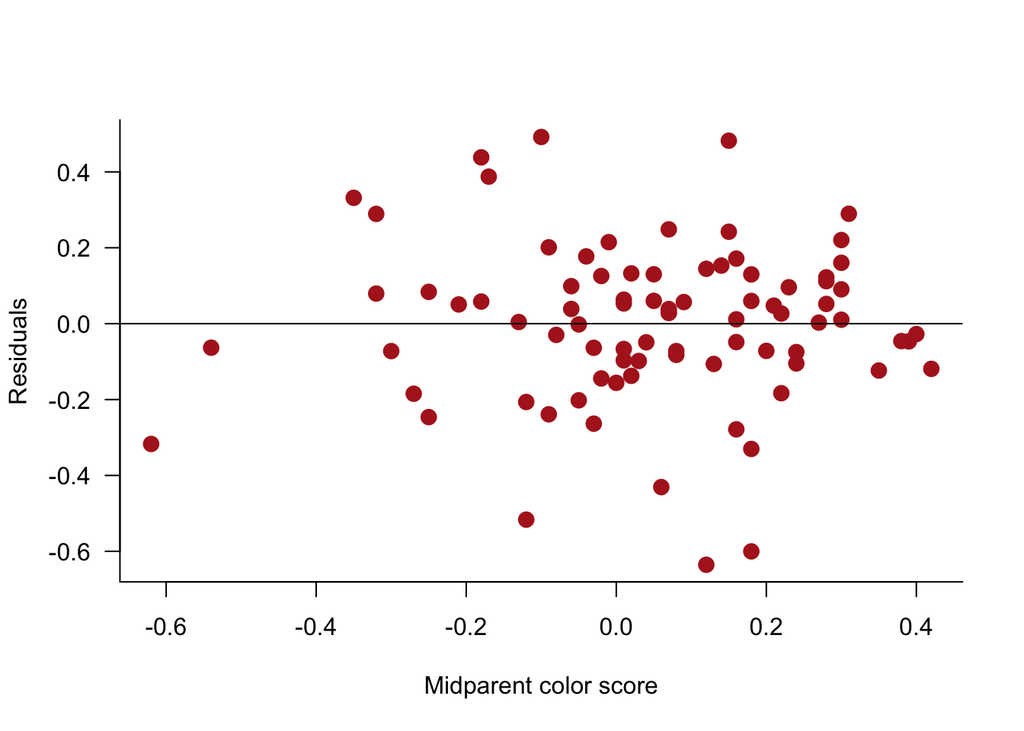

```r
plot(residuals(capColorRegression) ~ midparentColorScore, data = d,
     pch = 16, col = "firebrick", las = 1, cex = 1.5, bty = "l",
     xlab = "Midparent color score", ylab = "Residuals")
abline(c(0,0))
```

Examine the effect on an outlier on linear regression. The data are percentage of white in the tail feathers of the dark-eyed junco at sites at different latitudes.

Read and inspect data:

```r
junco <- read.csv("junco.csv")
head(junco)
```

```
##   X latitude percentWhiteTail
## 1 1     33.7             46.2
## 2 2     32.8             45.2
## 3 3     32.9             44.0
## 4 4     33.7             42.6
## 5 5     34.3             42.5
## 6 6     35.5             40.9
```

Scatter plot of all the data.

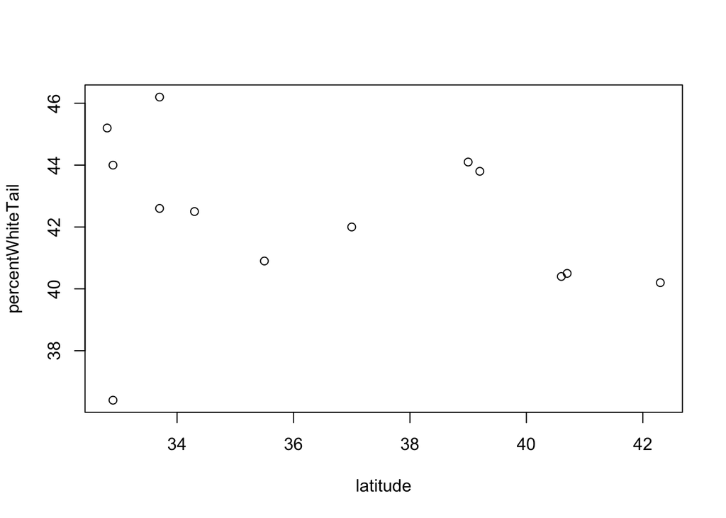

```r
plot(percentWhiteTail ~ latitude, data = junco)
```

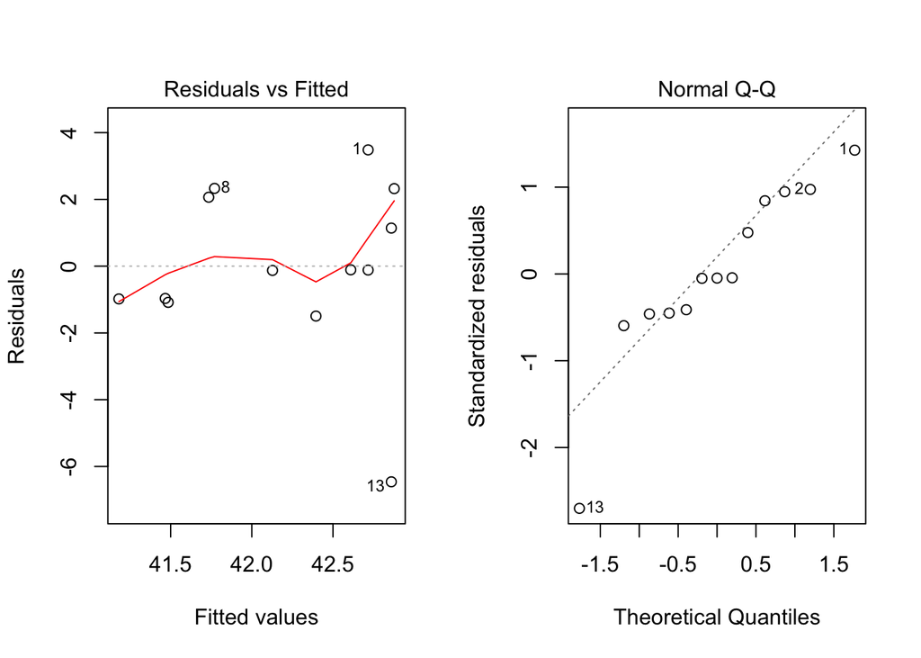

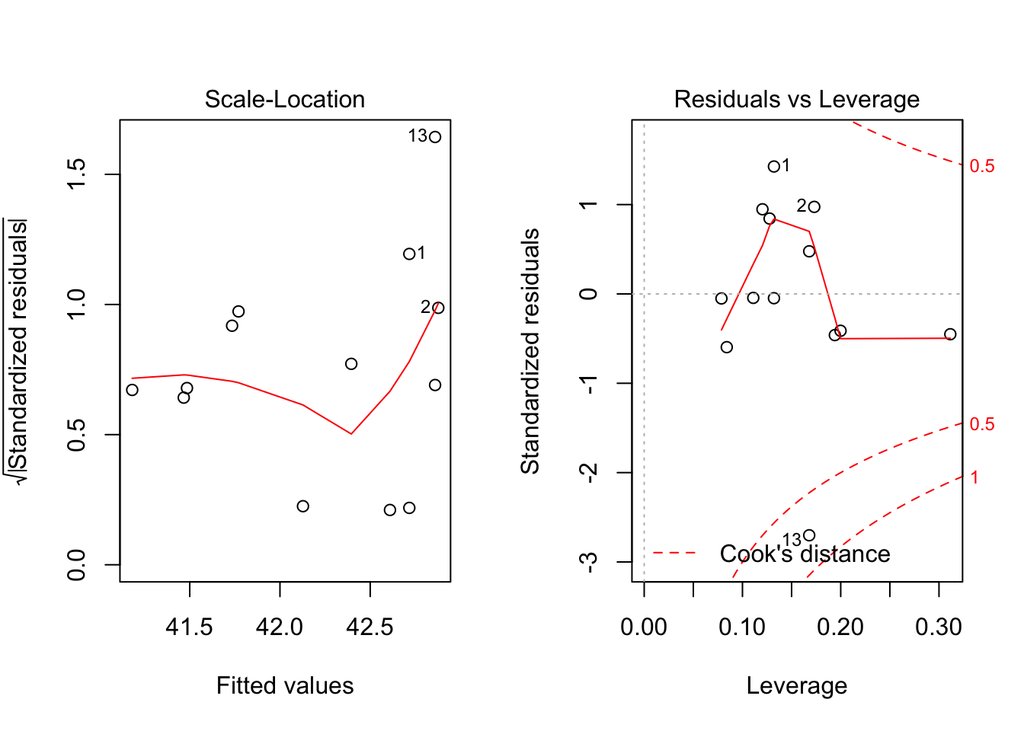

```r
juncoRegression <- lm(percentWhiteTail ~ latitude, data = junco)
oldpar<-par()
par(mfrow=c(1,2))
plot(juncoRegression)
```

From the diagnostic plots, it is apparent that one data point is influence. See the 4th plot above, where one point has an elevated “Cook’s distance”.

In general use, those observations that have a cook’s distance greater than 4 times the mean cook’s distances may be classified as influential. This is not a hard boundary.

Alternatively you can calculate the Cook’s distance from the regression fit:

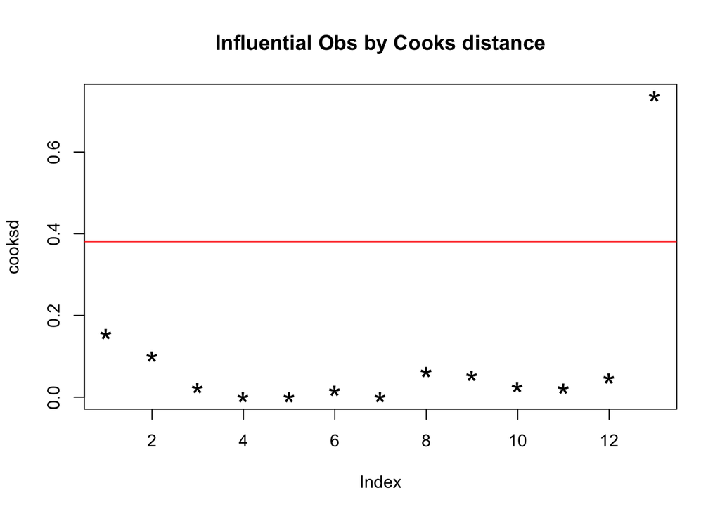

```r
cooksd<-cooks.distance(juncoRegression)
plot(cooksd, pch="*", cex=2, main="Influential Obs by Cooks distance")
abline(h = 4*mean(cooksd, na.rm=T), col="red")
text(x=1:length(cooksd)+1, y=cooksd, labels=ifelse(cooksd>4*mean(cooksd, na.rm=T),names(cooksd),""), col="red")
```

Knowing that one of the data points is influential, it could be removed.

Let’s add regression lines to this scatter plot, calculated both with and without the outlier. You may need to redraw the scatter plot using the above commands before executing the following functions. The two lines below demonstrate the influence of including (red) and removing (black) the influential point:

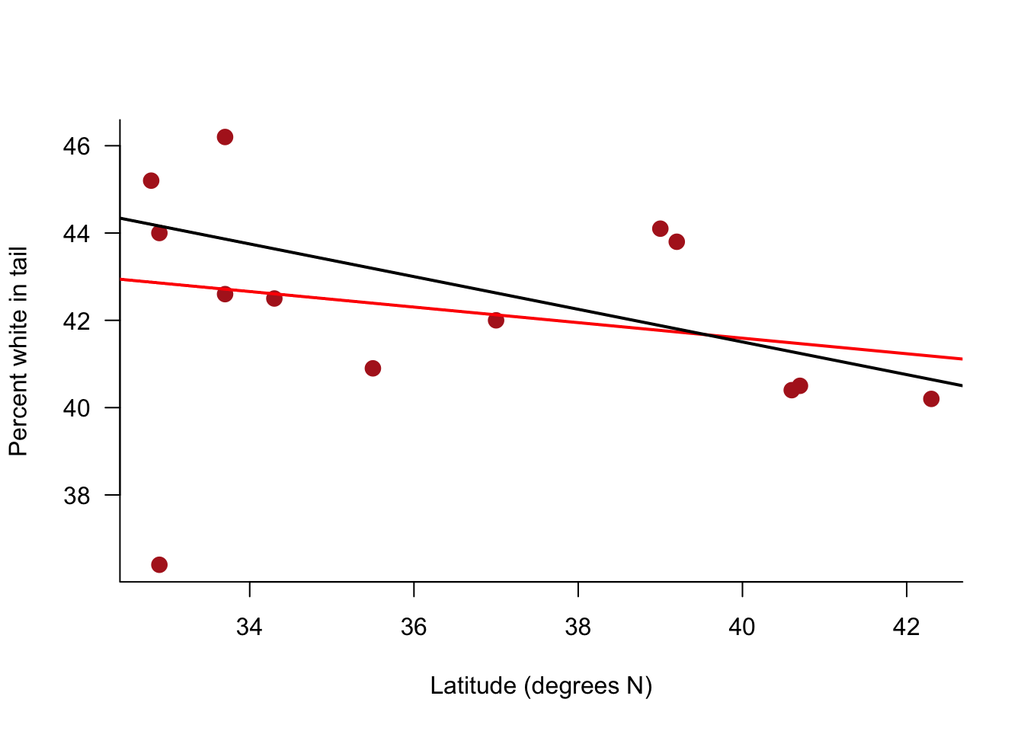

```r
plot(percentWhiteTail ~ latitude, data = junco, pch = 16, col="firebrick",
     las = 1, cex = 1.5, bty = "l", xlab = "Latitude (degrees N)",
     ylab = "Percent white in tail")
juncoRegression <- lm(percentWhiteTail ~ latitude, data = junco)
abline(juncoRegression, col = "red", lwd = 2)
juncoRegressionNoOut <- lm(percentWhiteTail ~ latitude,
                           data = junco, subset = percentWhiteTail > 38)
abline(juncoRegressionNoOut, lwd = 2)
```

## Plot residuals to check assumptions

- Whitlock and Schluter - 17.5-4

Read and inspect the data. The data are temperature and the firing rate of neurons in cockroach.

```r
roach <- read.csv("roach.csv")
```

Scatter plot with regression line.

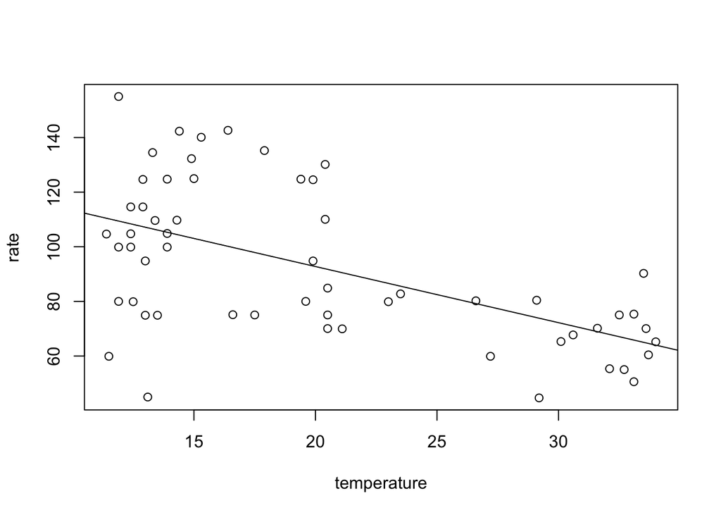

```r
plot(rate ~ temperature, data = roach)
roachRegression <- lm(rate ~ temperature, data = roach)
abline(roachRegression)
```

Make a residual plot to check assumptions.

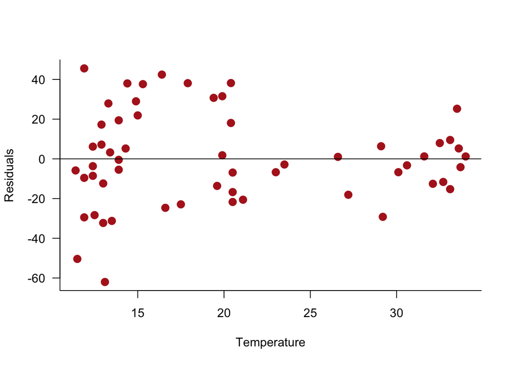

```r
plot(residuals(roachRegression) ~ temperature, data = roach,
     pch = 16, col = "firebrick", las = 1, cex = 1.5, bty = "l",
     xlab = "Temperature", ylab = "Residuals")
abline(c(0,0))
```

## Transformation to improve regression fit

Read and inspect data.

```r
iris <- read.csv("iris.csv")
str(iris)
```

```
## 'data.frame':    74 obs. of  3 variables:
##  $ X              : int  1 2 3 4 5 6 7 8 9 10 ...
##  $ tubeLengthMm   : int  38 54 53 55 64 64 57 51 49 47 ...
##  $ grainsDeposited: int  299 205 167 122 129 64 32 91 87 68 ...
```

Scatter plot with regression line.

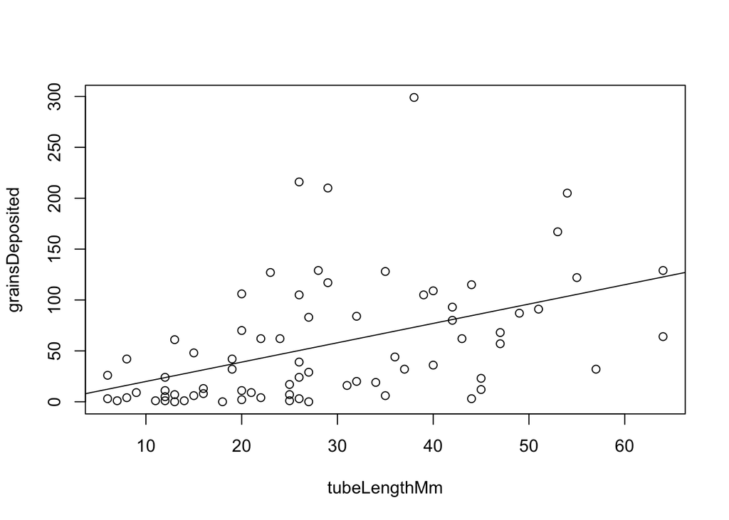

```r
plot(grainsDeposited ~ tubeLengthMm, data = iris)
irisRegression <- lm(grainsDeposited ~ tubeLengthMm, data = iris)
abline(irisRegression)
```

Residual plot:

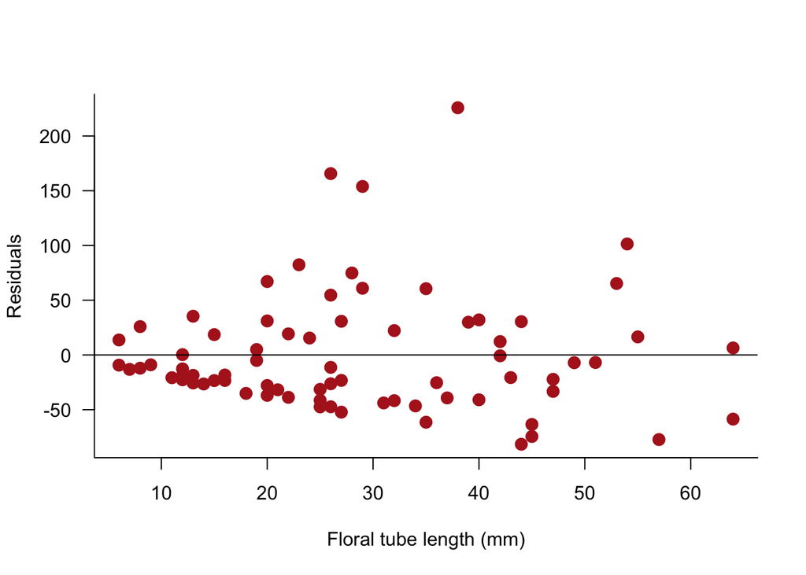

```r
plot(residuals(irisRegression) ~ tubeLengthMm, data = iris, pch = 16,
     col = "firebrick", las = 1, cex = 1.5, bty = "l",
     xlab = "Floral tube length (mm)", ylab = "Residuals")
abline(c(0,0))
```

Use a square root transformation to improve the fit to assumptions of linear regression. The data are number of pollen grains received and floral tube length of an iris species.

```r
iris$sqRootGrains <- sqrt(iris$grainsDeposited + 1/2)
```

Scatter plot using transformed data, with new regression line added.

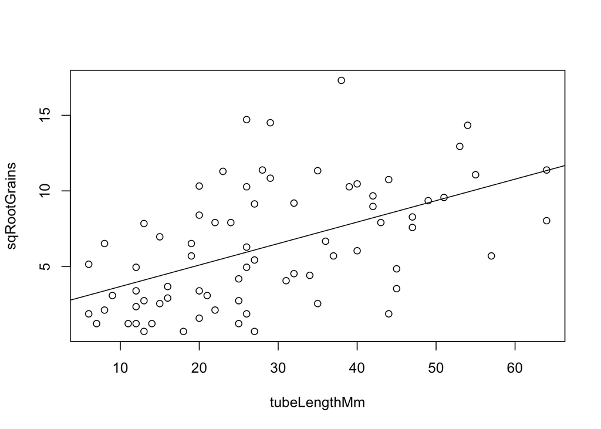

```r
plot(sqRootGrains ~ tubeLengthMm, data = iris)
irisRegressionSqrt <- lm(sqRootGrains ~ tubeLengthMm, data = iris)
abline(irisRegressionSqrt)
```

Residual plot based on the transformed data.

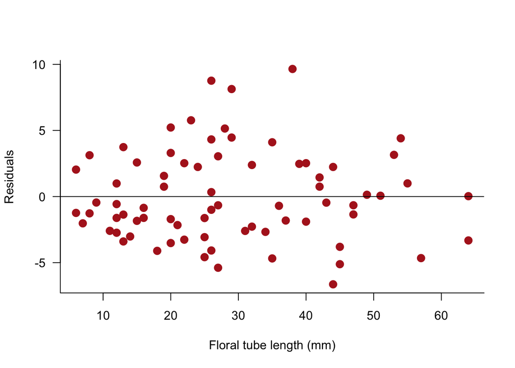

```r
plot(residuals(irisRegressionSqrt) ~ tubeLengthMm, data = iris,
     pch= 16, col = "firebrick", las = 1, cex=1.5, bty = "l",
     xlab = "Floral tube length (mm)", ylab = "Residuals")
abline(c(0,0))
```

## ANCOVA is a Linear Model

- from Whitlock and Schluter…

Analyze a factor while adjusting for a covariate, comparing energy expenditure of two castes of naked mole-rat while adjusting for differences in body mass using analysis of covariance ANCOVA.

Read and inspect the data.

```r
d <- read.csv("molerat.csv")
head(d)
```

```
##   X  caste   lnMass lnEnergy
## 1 1 worker 3.850148 3.688879
## 2 2 worker 3.988984 3.688879
## 3 3 worker 4.110874 3.688879
## 4 4 worker 4.174387 3.663562
## 5 5 worker 4.248495 3.871201
## 6 6 worker 4.262680 3.850148
```

We are going to sort the data according to the value of the ln of body mass. This simplifies graphing of the model fits. The graph commands below assume that the data are sorted in this way.

```r
moleRatSorted <- d[ order(d$lnMass), ]
```

Scatter plot of the data.

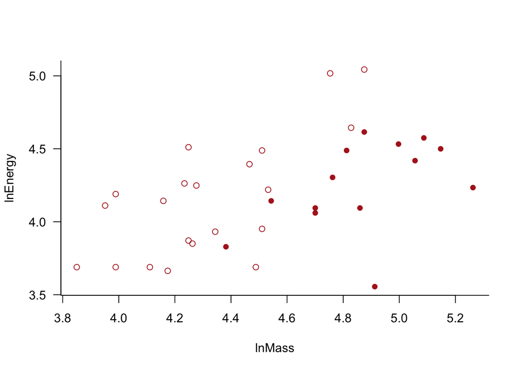

```r
plot(lnEnergy ~ lnMass, data = d, type = "n", las = 1, bty = "l")
points(lnEnergy ~ lnMass, data = subset(moleRatSorted, caste == "worker"),
       pch = 1, col = "firebrick")
points(lnEnergy ~ lnMass, data = subset(moleRatSorted, caste == "lazy"),
       pch = 16, col = "firebrick")
```

Fit models to the data, beginning with the model lacking an interaction term. Use lm because caste and mass are fixed effects. Save the predicted values in the data frame.

```r
moleRatNoInteractModel <- lm(lnEnergy ~ lnMass + caste, data = moleRatSorted)
moleRatSorted$predictedNoInteract <- predict(moleRatNoInteractModel)
```

Fit the full model, which includes the interaction term. Again, save the predicted values in the data frame.

```r
moleRatFullModel <- lm(lnEnergy ~ lnMass * caste, data = moleRatSorted)
moleRatSorted$predictedInteract <- predict(moleRatFullModel)
```

Visualize the model fits, beginning with the fit of the no-interaction model. Redraw the scatter plot (see commands above), if necessary, before issuing the following commands.

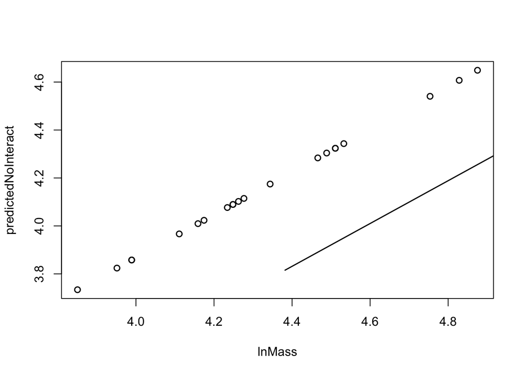

```r
plot(predictedNoInteract ~ lnMass, data = subset(moleRatSorted,
                                                  caste == "worker"), lwd = 1.5)
lines(predictedNoInteract ~ lnMass, data = subset(moleRatSorted,
                                                  caste == "lazy"), lwd = 1.5)
```

Visualize the fit of the full model, including the interaction term. Redraw the scatter plot, if necessary, before issuing the following commands.

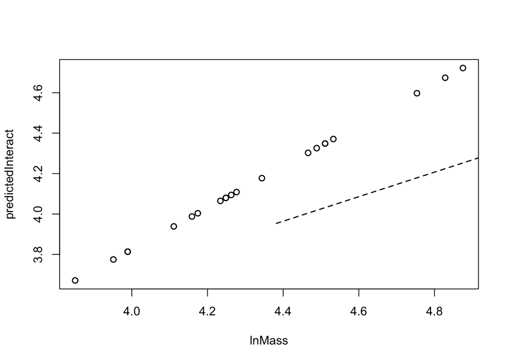

```r
plot(predictedInteract ~ lnMass, data = subset(moleRatSorted,
                                                caste == "worker"), lwd = 1.5, lty = 2)
lines(predictedInteract ~ lnMass, data = subset(moleRatSorted,
                                                caste == "lazy"), lwd = 1.5, lty = 2)
```

Test the improvement in fit of the full model, including the interaction term. This is a test of the interaction term only.

```r
anova(moleRatNoInteractModel, moleRatFullModel)
```

```
## Analysis of Variance Table
##
## Model 1: lnEnergy ~ lnMass + caste
## Model 2: lnEnergy ~ lnMass * caste
##   Res.Df    RSS Df Sum of Sq      F Pr(>F)
## 1     32 2.8145
## 2     31 2.7249  1  0.089557 1.0188 0.3206
```

Test using “Type III” sums of squares. We need to include a contrasts argument for the categorical variable in the lm command. Then we need to load the car package and use its Anova command. Note that “A” is in upper case in Anova().

```r
moleRatNoInteractModelTypeIII <- lm(lnEnergy ~ lnMass + caste, data = d,
                                    contrasts = list(caste = contr.sum))
library(car)
Anova(moleRatNoInteractModelTypeIII, type = "III")
```

```
## Anova Table (Type III tests)
##
## Response: lnEnergy
##              Sum Sq Df F value    Pr(>F)
## (Intercept) 0.00111  1  0.0126    0.9112
## lnMass      1.88152  1 21.3923 5.887e-05 ***
## caste       0.63747  1  7.2478    0.0112 *
## Residuals   2.81450 32
## ---
## Signif. codes:  0 '***' 0.001 '**' 0.01 '*' 0.05 '.' 0.1 ' ' 1
```

```r
# note "A" in Anova is capitalized
```

Test using “Type I” (sequential) sums of squares. Make sure that the covariate (lnMass) comes before the factor (caste) in the lm formula, as shown. Note that “a” is in lower case in anova.

```r
moleRatNoInteractModel <- lm(lnEnergy ~ lnMass + caste, data = d)
anova(moleRatNoInteractModel)
```

```
## Analysis of Variance Table
##
## Response: lnEnergy
##           Df  Sum Sq Mean Sq F value    Pr(>F)
## lnMass     1 1.31061 1.31061 14.9013 0.0005178 ***
## caste      1 0.63747 0.63747  7.2478 0.0111984 *
## Residuals 32 2.81450 0.08795
## ---
## Signif. codes:  0 '***' 0.001 '**' 0.01 '*' 0.05 '.' 0.1 ' ' 1
```

Residual plot from the linear model.

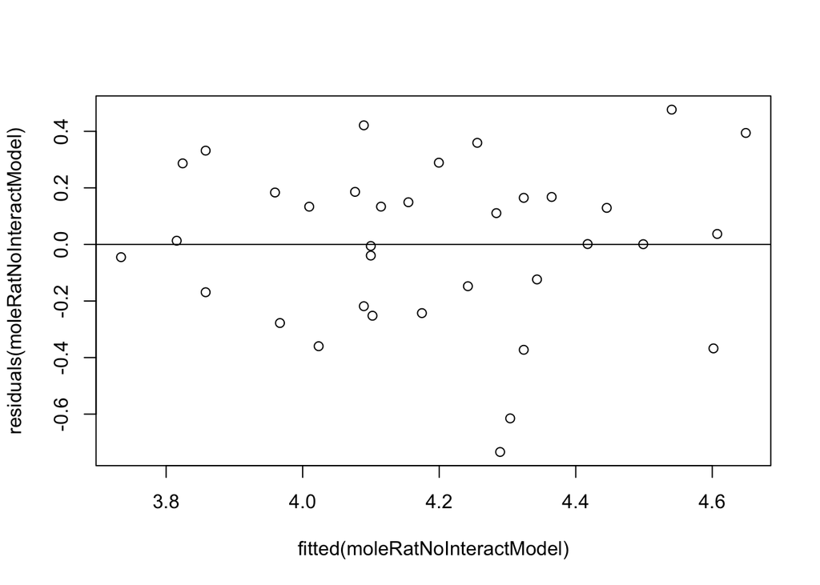

```r
plot( residuals(moleRatNoInteractModel) ~ fitted(moleRatNoInteractModel) )
abline(0,0)
```

Normal quantile plot of residuals.

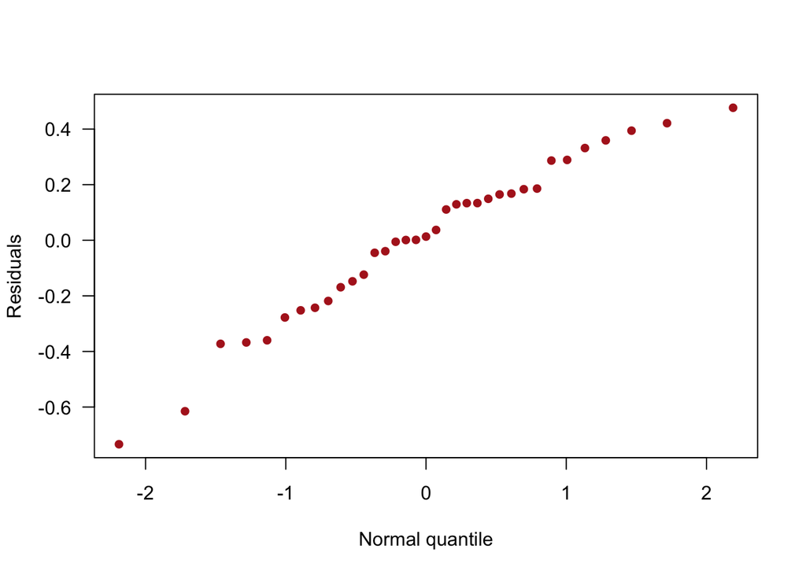

```r
qqnorm(residuals(moleRatNoInteractModel), pch = 16, col = "firebrick",
       las = 1, ylab = "Residuals", xlab = "Normal quantile", main = "")
```